# Introduction to R Programming

Author : Moses Kioko

Date : November 10, 2020

# 1 Introduction to R Programming

This markdown file focus on introduction of R Programming language by tackling the major aspects of statistical programming. The following topics will be covered in the course of this lecture. To access google slides for the lecture please follow this [link](https://docs.google.com/presentation/d/1pEJUoejwYzyqjX3Hk7oUcgQwmq8VUlkyJZHahKav-Zc/edit?pli=1#slide=id.ga7394a65b4_0_577)

**Topics Covered**

The table below shows a brief description of the content to be covered.

| Topic | Description |
| --- | --- |
| R step up | Downloading and Installing the R interface and relevant packages |
| R Syntax | getting acquitted with operators in R language |
| Importing and Exporting | Bringing data in and out of R environment |
| Wrangling / Munging | Process of preparing data ready for analysis |
| Functions | Helping to keep code neat and smaller |
| Merging & appending data-sets | Compiling data-sets by bringing together different tables by unique identifier |

# 2 R setup

## 2.1 Downloading and Installing R

To set up functional R work-flow you need to download and install the following;

- [Base R](https://cran.r-project.org/bin/windows/base/) - creates environment for statistical computing and visualization
- [Rstudio](https://rstudio.com/products/rstudio/download/) - It is wrapper upon which base R runs on
- [R Tools](https://cran.r-project.org/bin/windows/Rtools/) - links up base R and other languages *i.e* python

## 2.2 Setting Up work Environment

Setting up working environment entails clearing the working space and setting a working directory from where you can launch scripting of your projects comfortably.

```r
#clearing the working environment all objects in environment
rm(list = ls(all=TRUE))


#setting working directory
## Step I: Print current working directory
getwd()
```

```
## [1] "D:/pwani data collection/Pwani Analysis"
```

```r
## Step II: set new working directoy
setwd('D:/pwani data collection/Pwani Analysis')

## Step III: Confirm if youre on desired working directory by running
#getwd()
```

## 2.3 Installing and Loading Packages

R is a functional language that facilitate munging and computational analysis of data.To run any analysis or data manipulation you have to install **relevant Packages**, which have in-build functions that aid in performing specific tasks. One of the main packages in R is [Tidyverse Package](https://www.tidyverse.org/packages/) complied by `Hadley Wickham`. The package is crafted by combining different packages that are essential in wrangling and analyzing data-sets, they include;

- dplyr package
- tidyr package
- ggplot2 package
- readr package
- forcats package
- tibble package
- purr package

### 2.3.1 Github

Installing packages from github requires a prior installation of either remotes or devtools package. However, this method may not be so effective especially when it comes to updating the packages.

```r
# install remotes or devtools
#install.packages('devtools', dependencies = TRUE)
#install.packages('remotes', dependencies = TRUE)

#load the packages
library(remotes) # or
library(devtools)

# installing specific packages in r from github
#devtools::install_github("tidyverse/tidyverse")

#load the tidyverse package
library(tidyverse)
```

### 2.3.2 CRAN

Cran is the main repository where most of packages are housed for download in R.To install packages from CRAN please follow the attached example.

```r
# install package from Tidyverse from cran
#install.packages('tidyverse', dependencies = TRUE)

#installing multiple packages from cran
#install.packages(c('tidyverse','lubridate'), dependencies = TRUE)

#loading different packages
library(tidyverse)
```

# 3 Import and Export Data

Importing the data entails bringing in the data to R environment, the procedure of doing so its purely dependent on the file you want to import. There are several packages that are used to import/export data in R and such include;

| Package | Type of files |
| --- | --- |
| readr package | Imports and exports CSV files |
| readxl package | Imports .xls and .xlsx files. |
| haven package | Imports stata files*(.dta)*, spss files among others |
| jsonlite package | Imports json files |
| rio package | Imports and writes majority of files *i.e* excel, csv files …*etc* |
| feather package | Import python files |
| rvest package | used for web scrapping |
| xml2 package | Imports xml files |

```r
#exporting different methods of importing data

#step I: load the respective library
library(readxl) # for excel files
library(readr) #for csv files
library(rio)
rio::install_formats()
```

```
## [1] TRUE
```

```r
#import data
fish_data <- readxl::read_excel('Fish Data.xlsx', sheet = 'raw data')
one_species <- readxl::read_excel('One Fish Species.xlsx')
```

**please note ;** you can skip a row while importing the data as indicated in the example below. It is also worth noting that with Microsoft Excel workbooks you can read data from different sheets independently by specifying the sheet which contains the data.

```r
#skipping row 1 in coordinate data
coordinates <- readxl::read_excel('Fish Data.xlsx', sheet = 'coordinates',skip = 1)
```

# 4 Scanning Data

Scanning data basically entails, checking out for;

- Data Types
- Outliers
- Missing Values

## 4.1 Data types

Data types are helpful to the programmer for understanding the type of data s/he is handling or manipulating.Unlike statistically typed languages, R derives the data type of the variable implicitly from the R object assigned to the variable.

| Data Type | Example | Description | Verify |
| --- | --- | --- | --- |
| Logical | True *or* False | Boolean Values | v <- TRUE, print(class(x)) produces result `logical` |
| Numeric | 2, 2.0,2.22 | Numbers of all Kinds | v <- 23.5, print(class(v)), produces result `numeric` |
| Integer | 1L, 2L | Explicitly integers | v <- 2L, print(class(v)), produces result `interger` |
| Complex | 8 + 5i | Real Value + Complex Value | v <- 2+5i,print(class(v)),produces result `complex` |
| Character | “yes”,“no” | Characters and Strings | v <- “yes”,print(class(v)), produces result `character` |

To print all the data types in a data frame you can run `str command` as illustrated in the example below

```r
#check data types
str(fish_data)
```

```
## tibble [259 x 14] (S3: tbl_df/tbl/data.frame)
##  $ Date            : chr [1:259] "2020-06-16T00:00:00Z" "2020-06-16T00:00:00Z" "2020-06-16T00:00:00Z" "2020-06-16T00:00:00Z" ...
##  $ Boat type       : chr [1:259] "Dugout canoe" "Dugout canoe" "Dugout canoe" "Dugout canoe" ...
##  $ Gear type       : chr [1:259] "Reef seine" "Reef seine" "Reef seine" "Reef seine" ...
##  $ No. fishers     : num [1:259] 5 NA NA NA NA NA NA NA 23 NA ...
##  $ Area            : chr [1:259] "Gazi" "Gazi" "Gazi" "Gazi" ...
##  $ Fishing ground  : chr [1:259] "Chale" "Chale" "Chale" "Chale" ...
##  $ Month           : chr [1:259] "March" "March" "March" "March" ...
##  $ Season          : chr [1:259] "NEM" "NEM" "NEM" "NEM" ...
##  $ Species         : chr [1:259] NA "Euthynus affinis" "Caranx ignobilis" "Thunnus albacares" ...
##  $ Family          : chr [1:259] NA "Scombridae" "Carangidae" "Scombridae" ...
##  $ Total catch_kg  : num [1:259] 35 4.7 6.4 4.7 1.6 1.6 1.6 14.4 118 68.8 ...
##  $ Sample weight_kg: num [1:259] NA 6 5 4 2 2.5 1.5 5 NA 4 ...
##  $ Sample No.      : num [1:259] NA 3 4 3 1 1 1 9 NA 14 ...
##  $ Total pieces    : num [1:259] NA 7 6 5 2 3 2 6 NA 286 ...
```

## 4.2 Outliers

Outliers are values that are way behold the normal range of expected values, to spot this you plot a distribution plot or run a descriptive analysis. *please note that outliers are majorly numerical values*.For this example we will use base R commands to plot the data

**Scatter Plot**

The attached scatter plot indicates that most of fish had weight of less than 40Kg. However, some had weight of over 40kg which is an indicator for outliers.

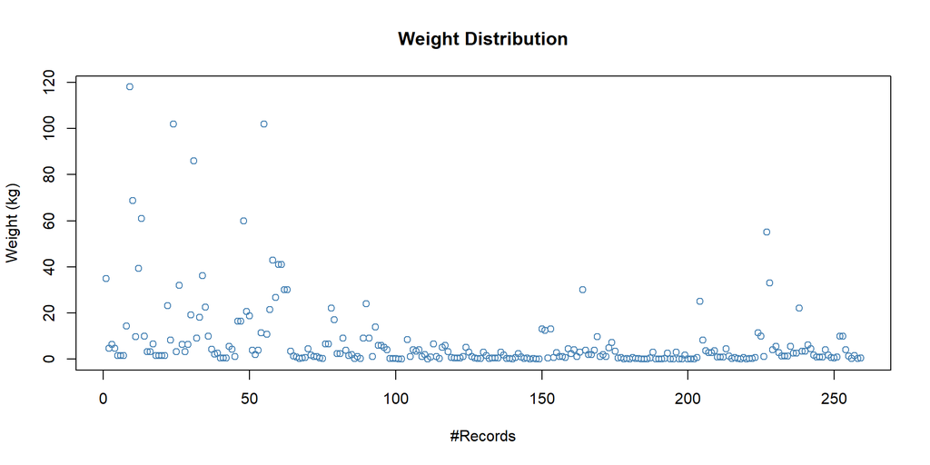

```r
#scatter plot
plot(fish_data$`Total catch_kg`,
     main = 'Weight Distribution',
     ylab ='Weight (kg)',
     xlab = '#Records',
     col ='steelblue')
```

**Box Plot**

Distribution of weight over species family is mapped in the boxplot below, from the plot it is evident that there is presence of outliers in the distribution as some of the points fall outside the boxplot in respective families.

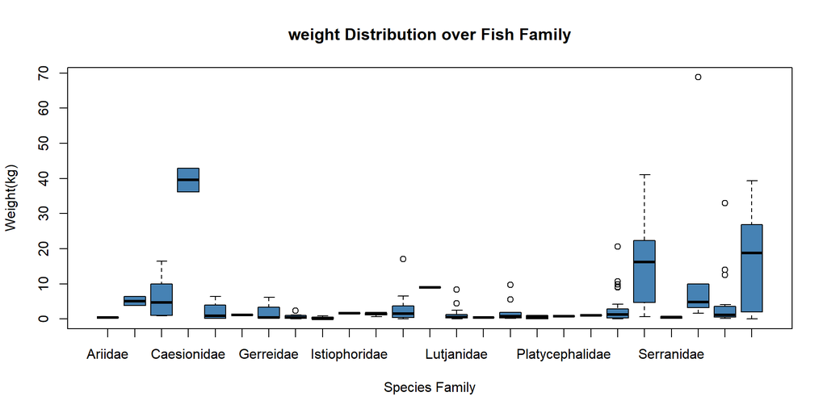

```r
#box plot
boxplot(`Total catch_kg`~ Family , data = fish_data,
        ylab = 'Weight(kg)',
        xlab = 'Species Family',
        col ='steelblue')

title("weight Distribution over Fish Family")
```

## 4.3 Missing Values

Missing values are simply all the Na or NAN values in a dataset, this values might lead to inaccurate analysis therefore we either;

- Drop Missing Values
- Impute Missing Values

### 4.3.1 Drop missing values

Dropping missing values is the the advisable method of handling missing data. However, this is dependent on the size of the data-set. You can drop all the missing values in the whole data-set or you can drop missing values using a preferred column *or* variable.

There are several options of dropping missing variable;

- tidyr functions ~ drop_na
- base r functions ~ na.omit or complete_case
- dplyr filter functions

To plot the distribution of the missing data, we use *Amelia Package* missmap function .

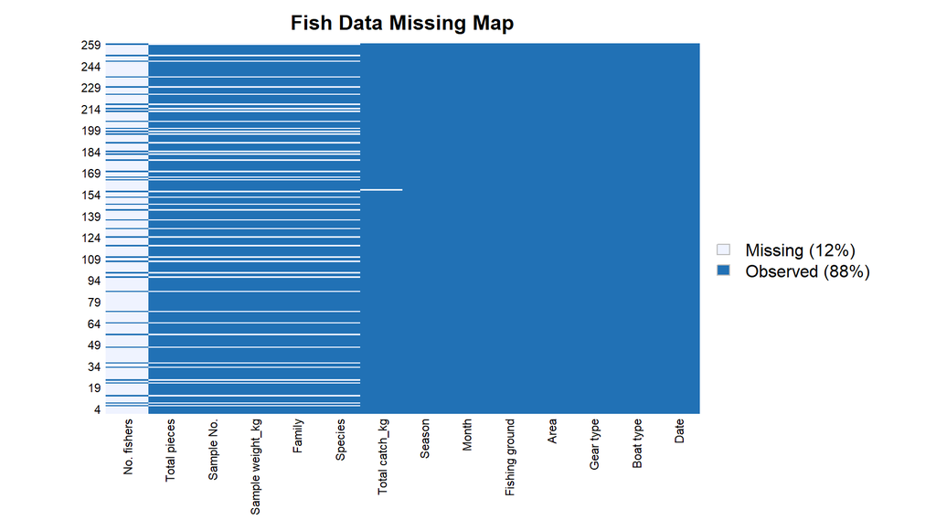

```r
#load the amelia package
library(Amelia)

Amelia::missmap(fish_data, main = 'Fish Data Missing Map',y.cex = 0.7, x.cex = 0.7)
```

The miss plot attached above indicates that **12%** of the data was missing. There two ways in which we can drop the missing data either by dropping all missing data in the set or dropping missing values in specific column. However, our dataset is not that big, therefore we might end up over-reducing the data by a significant margin. This prompts us to consider the most vital variable that we can use drop the missing values and in our case its the species column.

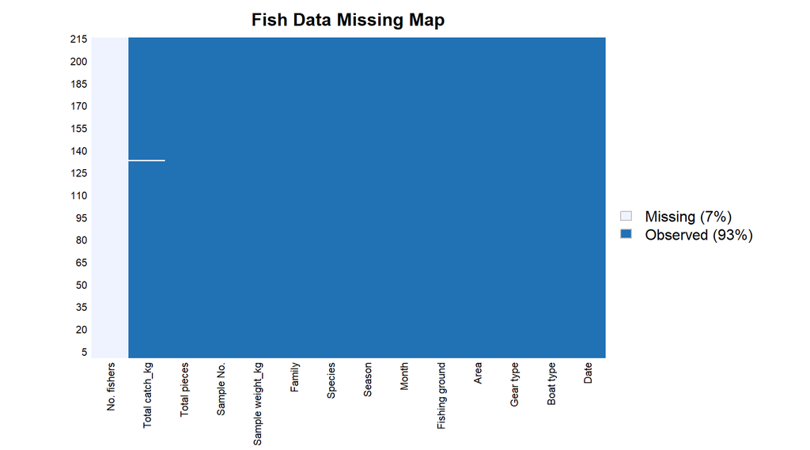

```r
#dropping missing values using fish species
fish_clean_data <- fish_data[complete.cases(fish_data$Species),]

#

Amelia::missmap(fish_clean_data, main = 'Fish Data Missing Map',y.cex = 0.7, x.cex = 0.7)
```

After dropping missing fish species it is evident that the percentage of missing values have significantly reduced from **12%** to **7%**,. However, you can notice that `No. of fishers` column have the majorly missing value.Therefore, we can drop the column.

After dropping the variable you can notice that we have **0%** missing values as indicated by the miss-plot below.

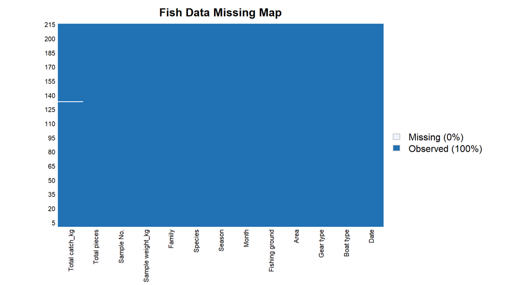

```r
#drop no of fisheries
fish_clean_data <- fish_clean_data %>%
  select(-`No. fishers`)


Amelia::missmap(fish_clean_data, main = 'Fish Data Missing Map',y.cex = 0.7, x.cex = 0.7)
```

### 4.3.2 Impute missing values

Imputing missing values is basically replacing missing values with pre-determined values. *i.e mean or median*. There are several packages that you can use to impute values they include;

- Amelia Package
- Hmisc Package

**Please note;** *This is not advisable method of dealing with missing values as it can contribute to wrong analysis*

# 5 Wrangling Data

Wrangling data is a process of pre-processing data before analysis, this is purely dependent on complexity of the data-set. In advanced stages it’s only ideal to run feature selection as part of data pre-processing which is purely applicable in large data-sets .In our case we will dwell on introductory part of data cleaning that entails;

- changing data formats
- changing text casing *i.e lowering the strings*
- changing date formats

we can have a general output of dataframe we working on, to do that we check on either the first few columns or the bottom column.

**Top 4 Rows**

```r
head(fish_clean_data,4)
```

```
## # A tibble: 4 x 13
##   Date  `Boat type` `Gear type` Area  `Fishing ground` Month Season Species
##   <chr> <chr>       <chr>       <chr> <chr>            <chr> <chr>  <chr>
## 1 2020~ Dugout can~ Reef seine  Gazi  Chale            March NEM    Euthyn~
## 2 2020~ Dugout can~ Reef seine  Gazi  Chale            March NEM    Caranx~
## 3 2020~ Dugout can~ Reef seine  Gazi  Chale            March NEM    Thunnu~
## 4 2020~ Dugout can~ Reef seine  Gazi  Chale            March NEM    Acanth~
## # ... with 5 more variables: Family <chr>, `Total catch_kg` <dbl>, `Sample
## #   weight_kg` <dbl>, `Sample No.` <dbl>, `Total pieces` <dbl>
```

```r
head(fish_clean_data,4)
```

```
## # A tibble: 4 x 13
##   Date  `Boat type` `Gear type` Area  `Fishing ground` Month Season Species
##   <chr> <chr>       <chr>       <chr> <chr>            <chr> <chr>  <chr>
## 1 2020~ Dugout can~ Reef seine  Gazi  Chale            March NEM    Euthyn~
## 2 2020~ Dugout can~ Reef seine  Gazi  Chale            March NEM    Caranx~
## 3 2020~ Dugout can~ Reef seine  Gazi  Chale            March NEM    Thunnu~
## 4 2020~ Dugout can~ Reef seine  Gazi  Chale            March NEM    Acanth~
## # ... with 5 more variables: Family <chr>, `Total catch_kg` <dbl>, `Sample
## #   weight_kg` <dbl>, `Sample No.` <dbl>, `Total pieces` <dbl>
```

## 5.1 Step I: Lowering the Variable Names

This is important simply because some of the variables have different character casing which would land us in trouble just in case we might need to merge the current data with other sets

```r
#lowering the variable names
clean_data <- fish_clean_data %>%
  select_all(tolower)
# to put the data in a nice table we can use reactable package
# install.package('reactable', dependencies=TRUE)
library(reactable)

#output  the table
reactable(clean_data[1:4,])
```

| date | boat type | gear type | area | fishing ground | month | season | species | family | total catch_kg | sample weight_kg | sample no. | total pieces |
| --- | --- | --- | --- | --- | --- | --- | --- | --- | --- | --- | --- | --- |
| 2020-06-16T00:00:00Z | Dugout canoe | Reef seine | Gazi | Chale | March | NEM | Euthynus affinis | Scombridae | 4.7 | 6 | 3 | 7 |
| 2020-06-16T00:00:00Z | Dugout canoe | Reef seine | Gazi | Chale | March | NEM | Caranx ignobilis | Carangidae | 6.4 | 5 | 4 | 6 |
| 2020-06-16T00:00:00Z | Dugout canoe | Reef seine | Gazi | Chale | March | NEM | Thunnus albacares | Scombridae | 4.7 | 4 | 3 | 5 |
| 2020-06-16T00:00:00Z | Dugout canoe | Reef seine | Gazi | Chale | March | NEM | Acanthocybium solandri | Scombridae | 1.6 | 2 | 1 | 2 |

## 5.2 Step II: Renaming

Renaming the variables in r you can use base R commands or use dplyr package rename function or select function , However, i would advise on using dplyr as it is easy to write and pipe to other commands in the pipeline

```r
#rename several variable name using rename fuction in dplyr
clean_data <- clean_data %>%
  rename(species_family = family,
         `total_weight(kg)` = `total catch_kg`,
         `sample_weight(kg)` = `sample weight_kg`,
         sample_no = `sample no.`,
         boat_type = `boat type`,
         gear_type = `gear type`,
         total_catch = `total pieces`,
         fishing_ground = `fishing ground`)

#output  the table
reactable(clean_data[1:4,])
```

| date | boat_type | gear_type | area | fishing_ground | month | season | species | species_family | total_weight(kg) | sample_weight(kg) | sample_no | total_catch |
| --- | --- | --- | --- | --- | --- | --- | --- | --- | --- | --- | --- | --- |
| 2020-06-16T00:00:00Z | Dugout canoe | Reef seine | Gazi | Chale | March | NEM | Euthynus affinis | Scombridae | 4.7 | 6 | 3 | 7 |
| 2020-06-16T00:00:00Z | Dugout canoe | Reef seine | Gazi | Chale | March | NEM | Caranx ignobilis | Carangidae | 6.4 | 5 | 4 | 6 |
| 2020-06-16T00:00:00Z | Dugout canoe | Reef seine | Gazi | Chale | March | NEM | Thunnus albacares | Scombridae | 4.7 | 4 | 3 | 5 |
| 2020-06-16T00:00:00Z | Dugout canoe | Reef seine | Gazi | Chale | March | NEM | Acanthocybium solandri | Scombridae | 1.6 | 2 | 1 | 2 |

## 5.3 Step III: Formatting variables

Varibles exist in different formas that might be unacceptable for visualization or even analysis, to counter this we change the variables types *i.e in our case date exist as a character which might be hard to plot or do any kind of time series related analysis*. To change the date type we might need help of base R commands or even [Lubricate Package](https://www.rdocumentation.org/packages/lubridate/versions/1.7.9) which is so handy in dealing with date variables

```r
#load lubridate package
library(lubridate)

#format dates
clean_data <- clean_data %>%
  mutate(date = as_date(date))

#output  the table
reactable(clean_data[1:4,])
```

| date | boat_type | gear_type | area | fishing_ground | month | season | species | species_family | total_weight(kg) | sample_weight(kg) | sample_no | total_catch |
| --- | --- | --- | --- | --- | --- | --- | --- | --- | --- | --- | --- | --- |
| 2020-06-16 | Dugout canoe | Reef seine | Gazi | Chale | March | NEM | Euthynus affinis | Scombridae | 4.7 | 6 | 3 | 7 |
| 2020-06-16 | Dugout canoe | Reef seine | Gazi | Chale | March | NEM | Caranx ignobilis | Carangidae | 6.4 | 5 | 4 | 6 |
| 2020-06-16 | Dugout canoe | Reef seine | Gazi | Chale | March | NEM | Thunnus albacares | Scombridae | 4.7 | 4 | 3 | 5 |
| 2020-06-16 | Dugout canoe | Reef seine | Gazi | Chale | March | NEM | Acanthocybium solandri | Scombridae | 1.6 | 2 | 1 | 2 |

## 5.4 Step IV: Word Casing

Word casing is changing the string case *i.e from lower to Upper case or from lower to capitalizing each word.*

```r
#changing casing
clean_data <- clean_data %>%
  #capitalize words
  mutate(boat_type = str_to_title(boat_type)) %>%
  mutate(gear_type = str_to_title(gear_type)) %>%
  mutate(area = str_to_title(area)) %>%
  mutate(fishing_ground =str_to_title(fishing_ground)) %>%
  #lower words
  mutate(species = str_to_lower(species)) %>%
  mutate(species_family =str_to_lower(species_family))

#output  the table
reactable(clean_data[1:4,])
```

| date | boat_type | gear_type | area | fishing_ground | month | season | species | species_family | total_weight(kg) | sample_weight(kg) | sample_no | total_catch |
| --- | --- | --- | --- | --- | --- | --- | --- | --- | --- | --- | --- | --- |
| 2020-06-16 | Dugout Canoe | Reef Seine | Gazi | Chale | March | NEM | euthynus affinis | scombridae | 4.7 | 6 | 3 | 7 |
| 2020-06-16 | Dugout Canoe | Reef Seine | Gazi | Chale | March | NEM | caranx ignobilis | carangidae | 6.4 | 5 | 4 | 6 |
| 2020-06-16 | Dugout Canoe | Reef Seine | Gazi | Chale | March | NEM | thunnus albacares | scombridae | 4.7 | 4 | 3 | 5 |
| 2020-06-16 | Dugout Canoe | Reef Seine | Gazi | Chale | March | NEM | acanthocybium solandri | scombridae | 1.6 | 2 | 1 | 2 |

## 5.5 Step V: labelling

Labeling help us to explore use of conditional functions to clean data by changing labels in datasets, in our case we use `if else` function that checks if the condition is true or false and return respective label assigned

```r
#labelling casing
clean_data <- clean_data %>%
  mutate(season = if_else(season == 'NEM','North East Monsoon ',
                          if_else(season == 'SEM','South East Monsoon ','unknown')))
#output  the table
reactable(clean_data[1:4,])
```

| date | boat_type | gear_type | area | fishing_ground | month | season | species | species_family | total_weight(kg) | sample_weight(kg) | sample_no | total_catch |
| --- | --- | --- | --- | --- | --- | --- | --- | --- | --- | --- | --- | --- |
| 2020-06-16 | Dugout Canoe | Reef Seine | Gazi | Chale | March | North East Monsoon | euthynus affinis | scombridae | 4.7 | 6 | 3 | 7 |
| 2020-06-16 | Dugout Canoe | Reef Seine | Gazi | Chale | March | North East Monsoon | caranx ignobilis | carangidae | 6.4 | 5 | 4 | 6 |
| 2020-06-16 | Dugout Canoe | Reef Seine | Gazi | Chale | March | North East Monsoon | thunnus albacares | scombridae | 4.7 | 4 | 3 | 5 |
| 2020-06-16 | Dugout Canoe | Reef Seine | Gazi | Chale | March | North East Monsoon | acanthocybium solandri | scombridae | 1.6 | 2 | 1 | 2 |

**Cleaning Coordinate Data**

```r
#output  the table
reactable(coordinates)
```

| Major fishing ground | Sub fishing ground | latitude | longitude | Corals | seagrass | sand | Rocks |
| --- | --- | --- | --- | --- | --- | --- | --- |
| MSANGANI | Mkingamo | 4.46021 | 39.52947 | NA | NA | NA | NA |
| NA | Kijatuni/Kijambamkande | 4.46096 | 39.53089 | NA | NA | NA | NA |
| NA | Kifunguni | 4.45917 | 39.5194 | NA | NA | NA | NA |
| NA | Kukuni | 4.44385 | 39.53089 | NA | NA | NA | NA |
| CHALE | NA | 4.44311 | 39.58655 | NA | NA | NA | NA |
| NA | Msumeno | 4.44098 | 39.54072 | NA | NA | NA | NA |
| NA | Mabotini | 4.44377 | 39.53861 | NA | NA | NA | NA |
| NA | Mlango mkavu | 4.44256 | 39.53663 | NA | NA | NA | NA |
| NA | Ngonda | 4.44428 | 39.5278 | NA | NA | NA | NA |
| NA | Maji makubwa | 4.44127 | 39.52498 | NA | NA | NA | NA |

[output cut: 9 more lines]

The table above is a composition of attributes for the coordinates different fishing grounds. The important variables include major fishing ground, sub fishing ground, latitude and longitude.

This Variables are selected and renamed at the same time using `select` command in `dyplr` that ensures you select the desired fields and assign them to names of your choice as illustrated by the example below

```r
#select only important varibles and rename
coordinates_data <- coordinates %>%
  dplyr::select(main_fishingground = `Major fishing ground`,
                sub_fishingground = `Sub fishing ground`,
                latitude,longitude)
#output  the table
reactable(coordinates_data)
```

| main_fishingground | sub_fishingground | latitude | longitude |
| --- | --- | --- | --- |
| MSANGANI | Mkingamo | 4.46021 | 39.52947 |
| NA | Kijatuni/Kijambamkande | 4.46096 | 39.53089 |
| NA | Kifunguni | 4.45917 | 39.5194 |
| NA | Kukuni | 4.44385 | 39.53089 |
| CHALE | NA | 4.44311 | 39.58655 |
| NA | Msumeno | 4.44098 | 39.54072 |
| NA | Mabotini | 4.44377 | 39.53861 |
| NA | Mlango mkavu | 4.44256 | 39.53663 |
| NA | Ngonda | 4.44428 | 39.5278 |
| NA | Maji makubwa | 4.44127 | 39.52498 |

[output cut: 9 more lines]

After selecting the variables and assigning them to preferred names the the casing of the records are capitalized to standardize the names.

```r
#tolower fishing ground names
coordinates_data <- coordinates_data %>%
  mutate(main_fishingground = str_to_title(main_fishingground)) %>%
  mutate(sub_fishingground = str_to_title(sub_fishingground))

#output  the table
reactable(coordinates_data)
```

| main_fishingground | sub_fishingground | latitude | longitude |
| --- | --- | --- | --- |
| Msangani | Mkingamo | 4.46021 | 39.52947 |
| NA | Kijatuni/Kijambamkande | 4.46096 | 39.53089 |
| NA | Kifunguni | 4.45917 | 39.5194 |
| NA | Kukuni | 4.44385 | 39.53089 |
| Chale | NA | 4.44311 | 39.58655 |
| NA | Msumeno | 4.44098 | 39.54072 |
| NA | Mabotini | 4.44377 | 39.53861 |
| NA | Mlango Mkavu | 4.44256 | 39.53663 |
| NA | Ngonda | 4.44428 | 39.5278 |
| NA | Maji Makubwa | 4.44127 | 39.52498 |

[output cut: 9 more lines]

## 5.6 Step VI: Reshape the Data

Reshaping data entails changing between long to wide formats and vice versa, this can be done using `tidyr package`, `splitstackshape` *or* `reshape` packages among others. In our case we will be using tidyr package to change wide format to long, this is illustrated in the example below.

```r
#transform data from wide to long
coordinates_long <- coordinates_data %>%
  pivot_longer(main_fishingground:sub_fishingground, names_to ='category', values_to = 'fishing_ground')

#output  the table
reactable(coordinates_long)
```

| latitude | longitude | category | fishing_ground |
| --- | --- | --- | --- |
| 4.46021 | 39.52947 | main_fishingground | Msangani |
| 4.46021 | 39.52947 | sub_fishingground | Mkingamo |
| 4.46096 | 39.53089 | main_fishingground | NA |
| 4.46096 | 39.53089 | sub_fishingground | Kijatuni/Kijambamkande |
| 4.45917 | 39.5194 | main_fishingground | NA |
| 4.45917 | 39.5194 | sub_fishingground | Kifunguni |
| 4.44385 | 39.53089 | main_fishingground | NA |
| 4.44385 | 39.53089 | sub_fishingground | Kukuni |
| 4.44311 | 39.58655 | main_fishingground | Chale |
| 4.44311 | 39.58655 | sub_fishingground | NA |

[output cut: 28 more lines]

**Filter Missing Fishing Ground**

```r
coordinates_long <- coordinates_long %>%
  #remove the missing fishing ground
  filter(str_length(fishing_ground)>2) %>%
  #unselect the category column
  select(-category)

#output  the table
reactable(coordinates_long)
```

| latitude | longitude | fishing_ground |
| --- | --- | --- |
| 4.46021 | 39.52947 | Msangani |
| 4.46021 | 39.52947 | Mkingamo |
| 4.46096 | 39.53089 | Kijatuni/Kijambamkande |
| 4.45917 | 39.5194 | Kifunguni |
| 4.44385 | 39.53089 | Kukuni |
| 4.44311 | 39.58655 | Chale |
| 4.44098 | 39.54072 | Msumeno |
| 4.44377 | 39.53861 | Mabotini |
| 4.44256 | 39.53663 | Mlango Mkavu |
| 4.44428 | 39.5278 | Ngonda |

[output cut: 9 more lines]

**Separate Combined Fishing Ground**

One of the collected GPS location was shared between two fishing ground hence we need to separate the location by splitting by the separating delimiter. Separate function helps us to accomplish this as illustrated by the example below

```r
coordinates_long <- coordinates_long %>%
  #separate the combined fishing fround
  separate(fishing_ground, into = c('ground_I','ground_II'),sep = '/')

#output  the table
reactable(coordinates_long)
```

| latitude | longitude | ground_I | ground_II |
| --- | --- | --- | --- |
| 4.46021 | 39.52947 | Msangani | NA |
| 4.46021 | 39.52947 | Mkingamo | NA |
| 4.46096 | 39.53089 | Kijatuni | Kijambamkande |
| 4.45917 | 39.5194 | Kifunguni | NA |
| 4.44385 | 39.53089 | Kukuni | NA |
| 4.44311 | 39.58655 | Chale | NA |
| 4.44098 | 39.54072 | Msumeno | NA |
| 4.44377 | 39.53861 | Mabotini | NA |
| 4.44256 | 39.53663 | Mlango Mkavu | NA |
| 4.44428 | 39.5278 | Ngonda | NA |

[output cut: 9 more lines]

**Combine Ground I and II**

We transform the the data again from wide format to long format and repeat the same procedure of selecting the fishing ground with values as well as un-selecting the category

```r
coordinates_long <-coordinates_long %>%
  #change wide to long
  pivot_longer(ground_I:ground_II, names_to ='category',values_to ='fishing_ground') %>%
  #unselect the missing fishing ground
  filter(!is.na(fishing_ground)) %>%
  #unselect the category
  select(-category) %>%
  #change the latitude to minus point
  mutate(latitude = 0-latitude)

#output  the table
reactable(coordinates_long)
```

| latitude | longitude | fishing_ground |
| --- | --- | --- |
| -4.46021 | 39.52947 | Msangani |
| -4.46021 | 39.52947 | Mkingamo |
| -4.46096 | 39.53089 | Kijatuni |
| -4.46096 | 39.53089 | Kijambamkande |
| -4.45917 | 39.5194 | Kifunguni |
| -4.44385 | 39.53089 | Kukuni |
| -4.44311 | 39.58655 | Chale |
| -4.44098 | 39.54072 | Msumeno |
| -4.44377 | 39.53861 | Mabotini |
| -4.44256 | 39.53663 | Mlango Mkavu |

[output cut: 10 more lines]

# 6 Merge

Merge dataset is combining two or more datasets by use of unique key variables that is present in both datasets. In R programming language this can be done by ;

| Types | Description |
| --- | --- |
| Inner Join | Return the records which matched between the two data frames |
| Left Join | Returns all of the rows from one table (the left side) and any matching rows from the second table |
| Right Join | Returns all of the rows from one table (the right side) and any matching rows from the second table |
| Full Join | Returns all of the rows from both tables |
| Anti Join | Returns all of the rows from one table (the left side) that do not have matching rows from the second table |

In our case we will use left join to bring the latitude and longitude from coordinate data frame and merge it using fishing ground as illustrated in example below.

```r
merged_data <- clean_data %>%
  left_join(coordinates_long, by ='fishing_ground')

#output  the table
reactable(merged_data[1:4,])
```

| date | boat_type | gear_type | area | fishing_ground | month | season | species | species_family | total_weight(kg) | sample_weight(kg) | sample_no | total_catch | latitude | longitude |
| --- | --- | --- | --- | --- | --- | --- | --- | --- | --- | --- | --- | --- | --- | --- |
| 2020-06-16 | Dugout Canoe | Reef Seine | Gazi | Chale | March | North East Monsoon | euthynus affinis | scombridae | 4.7 | 6 | 3 | 7 | -4.44311 | 39.58655 |
| 2020-06-16 | Dugout Canoe | Reef Seine | Gazi | Chale | March | North East Monsoon | caranx ignobilis | carangidae | 6.4 | 5 | 4 | 6 | -4.44311 | 39.58655 |
| 2020-06-16 | Dugout Canoe | Reef Seine | Gazi | Chale | March | North East Monsoon | thunnus albacares | scombridae | 4.7 | 4 | 3 | 5 | -4.44311 | 39.58655 |
| 2020-06-16 | Dugout Canoe | Reef Seine | Gazi | Chale | March | North East Monsoon | acanthocybium solandri | scombridae | 1.6 | 2 | 1 | 2 | -4.44311 | 39.58655 |

# 7 Next Class

Just to give an overview of what you expect in next section of class, See you then.

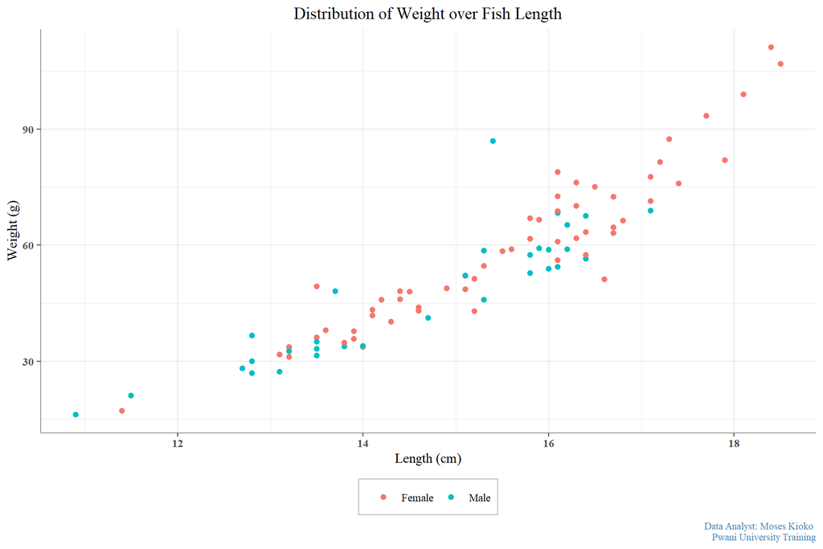

```r
##**cleaning siganus luridus data**
siganus_luridus <- one_species %>%
  #select the important variables
  select(species = Species,
         `length(cm)` = `Total length (cm)`,
         `weight(g)` = `Individual Wt (g)`,
         maturity = Maturity,
         gender = Sex,
         condition_factor = `condition factor`,
         fecundity = Fecundity) %>%
  #lower the species name
  mutate(species = str_to_lower(species))

#point plot
siganus_luridus %>%
  ggplot(aes(`length(cm)`,`weight(g)`, color = gender))+
  geom_point(size = 1.7)+
  labs(title = 'Distribution of Weight over Fish Length',
       y ='Weight (g)',
       x = 'Length (cm)',
       caption = 'Data Analyst: Moses Kioko \n Pwani University Training')+
  theme_minimal()+
  theme(legend.position = "bottom",
        legend.background = element_rect(color = "grey"),
        legend.title =  element_blank(),
        legend.text = element_text(family = "serif"),
        plot.title = element_text(hjust = 0.5,family = "serif"),
        axis.text = element_text(family = "serif", face = 'bold'),
        axis.title = element_text(family = "serif"),
        axis.line = element_line(colour = "grey30",size = .2),
        axis.ticks = element_line(colour = "grey30"),
        plot.subtitle = element_text(family = "serif",face = "italic",hjust = 0.5),
        plot.caption = element_text(size = 8,color = "steelblue",family = "serif"))
```

# 8 Resources

## 8.1 Book Links

To advance your skills in R programming i would advice you follow the attached links to explore more content on programming with R

| Type Of Book | Link |
| --- | --- |
| Hands on Programming with R | [Book Link](https://rstudio-education.github.io/hopr/) |
| Advanced R | [Book Link](https://adv-r.hadley.nz/) |
| Data Science Command Line | [Book Link](https://www.datascienceatthecommandline.com/1e/) |
| Efficient Programming with R | [Book Link](https://csgillespie.github.io/efficientR/) |
| Rmarkdown | [Book Link](https://bookdown.org/yihui/rmarkdown/) |

## 8.2 Tutor Contacts

The attached are my contacts you can reach out for further guidance

| Type | contact |
| --- | --- |
| Email Address | moseskioko94@gmail.com |
| Phone Number | +254702255489 |
| Profile | [profile Link](https://moseskitikukioko.github.io/) |
| LinkedIn | [Linkedin Link](https://www.linkedin.com/in/moseskitiku/) |
| Twitter | [Twitter Link](https://twitter.com/kioko_genius) |
| GitHub | [GitHub Link](https://github.com/MosesKitikuKioko) |